# Assessment review of Megrim (*Lepidorhombus whiffiagonis*) in Divisions 7.b-k, 8.a, 8.b, and 8.d

Author

Miren Altuna-Etxabe

Published

June 12, 2026

# Introduction

Since the WKMEGRIM benchmark in 2022 (ICES 2023), the assessment of Megrim in divisions 7.b-k, 8.a, 8.b, and 8.d has been conducted using an a4a model (Millar and Jardim 2019). While this model initially delivered acceptable results, the 2024 assessment began to show signs of concern, and by 2025, significant issues had already emerged - particularly in the retrospective pattern, which was deemed unacceptable by ACOM.

Consequently, in 2025 review level benchmark was conducted. The objective of the review-level benchmark was to diagnose the root causes of the retrospective bias and implement corrections to the data and/or model configuration to enhance the accuracy and reliability of the assessment.

Key Corrections: - Catch Data: Catch-at-age and weight data did not align with total reported catches. Adjustments were made to ensure consistency. - IRLFR Index: Included age classes outside the defined stock area. The index was re-estimated to exclude these individuals. - Porcupine Index: The plus group was incorrectly set at age 8. It was corrected to age 10 to match the appropriate age structure.

Model Modifications (a4a Sub-models): - Fishing Selectivity: A shift in weight-at-age around 2014 indicated a change in fishing patterns. Two time blocks were introduced-pre-2014 and post-2014-to reflect this. - Age-Class Inconsistencies: Surveys from 2015-2019 showed high numbers of young fish that did not appear in later catches or surveys. To improve model fit, data for ages 1-3 from 2015-2021 were removed. - Spline Function Knots: The impact of knot settings in spline functions was evaluated and updated to enhance model performance.

A comprehensive account of the assessment review conducted during the 2025 review-level benchmark is provided in Working Document WD12 (ICES 2025). Additionally, a detailed analysis of the reference points, calculated in accordance with the revised assessment framework, is available in Working Document WD13 (ICES 2025).

While these adjustments improved the overall model fit, they did not fully eliminate the retrospective bias. Further investigation is required to resolve remaining uncertainties.

This document starts presenting the results from the assessment model used in last year’s advice, updated with 2025 data. From there, proposed corrections and modifications are introduced progressively, each under its own dedicated section (e.g., catch data correction, index data re-estimated, selectivity adjustments, etc.). At every step, the impact of each change is evaluated using a set of diagnostic plots: the retrospective analysis, selectivity and catchability of indices, residuals, and observed versus predicted catches. This approach allows for a transparent and systematic assessment of how each modification influences model performance.

# Base case model

## Model configuration

The a4a model is defined by sub-model which require the definition of their mathematical structure. There are five sub-models in operation:

```r
fmod <- ~s(ifelse(year <= 2013 & age > 7, 7,
                  ifelse(year >= 2014 & age > 6, 6, age)), k = 3, by = breakpts(year, 2013)) + factor(year)
srmod <- ~ factor(year)
qmod <- list(~ I(1 / (1 + exp(-age))),~ I(1 / (1 + exp(-age))))
n1mod <- ~s(age, k = 3)
vmod <- list(~s(age, k = 3), ~1, ~1)
```

The fishing mortality-at-age model (fmodel) estimates selectivity-at-age using two different time blocks: one covering the historical period until 2013, and an-other from 2014 onwards. The shape of the F-at-age pattern is independently estimated for each age except ages 7 and older in the first period and except ag-es 6 and older in the second period, which are assumed to have the same F. This F pattern is then scaled up and down independently for each year.

Stock-recruitment model (srmodel) estimates independent recruitments for each year without any functional form (no stock-recruitment relationship).

Catchability models (qmodel) for both surveys [SpPGFS-WIBTS-Q4 (G5768) and the combined FR_IE_IBTS (G9527_G7212)] assumes a logistic model.

The population in the first year of the time-series model (n1model) uses the default value of a4aSCA function that estimates abundances independently for each age.

The model that controls the shape of the observation variances (vmodel) is also the default in a4aSCA function, a smooth function for the catch numbers-at-age and ‘flat’ for the indices.

## Retrospective analysis plot

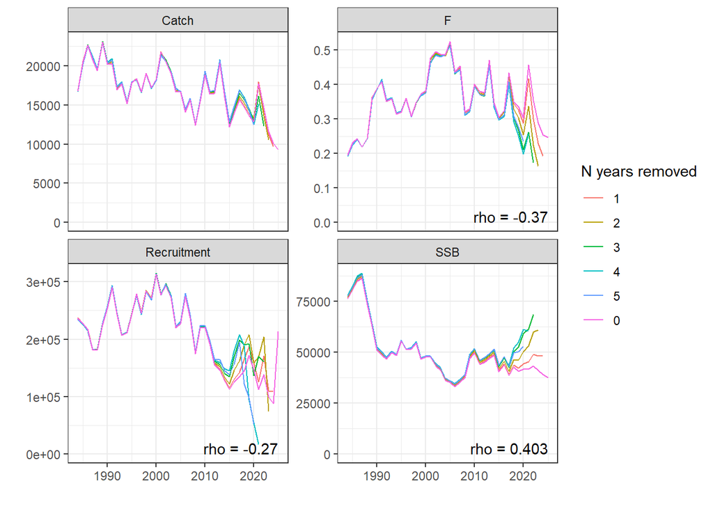

Figure 1: Retrospective analysis in the 2026 assessment, showing time series and Mohn’s rho values for median catch, fishing mortality (F, ages 3-6), recruitment (age 1), and spawning stock biomass (SSB).

## Selectivity and catchability plot

The fishery selectivity and catchabilities of the indices are shown in Figure 2.

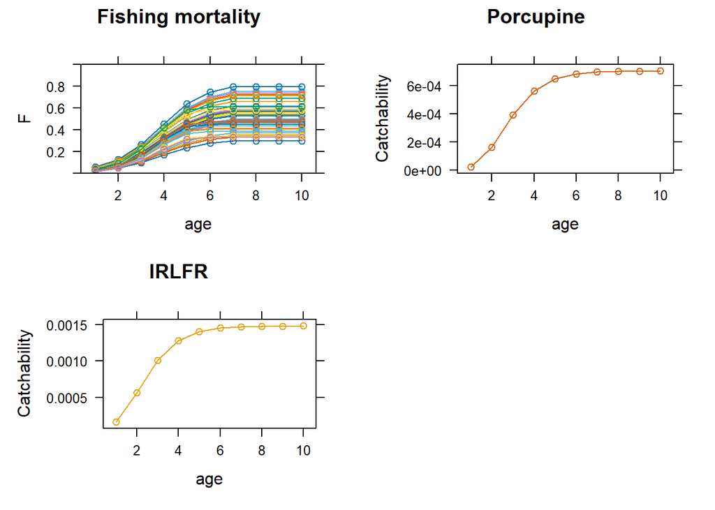

Figure 2: Fishery selectivity and indices catchabilities estimates in the 2026 assessment.

## Residuals plot

The catch-at-age and index-at-age residuals are shown in Figure 3.

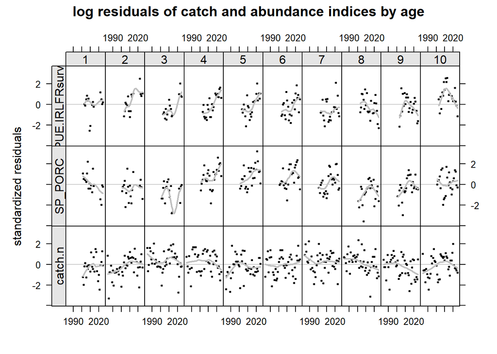

Figure 3: The catch-at-age and index-at-age (Porcupine and IRLFR) residuals in the 2026 assessment.

## Observed and predicted catches plot

The differences among observed and predicted catches are shown in (Figure 4).

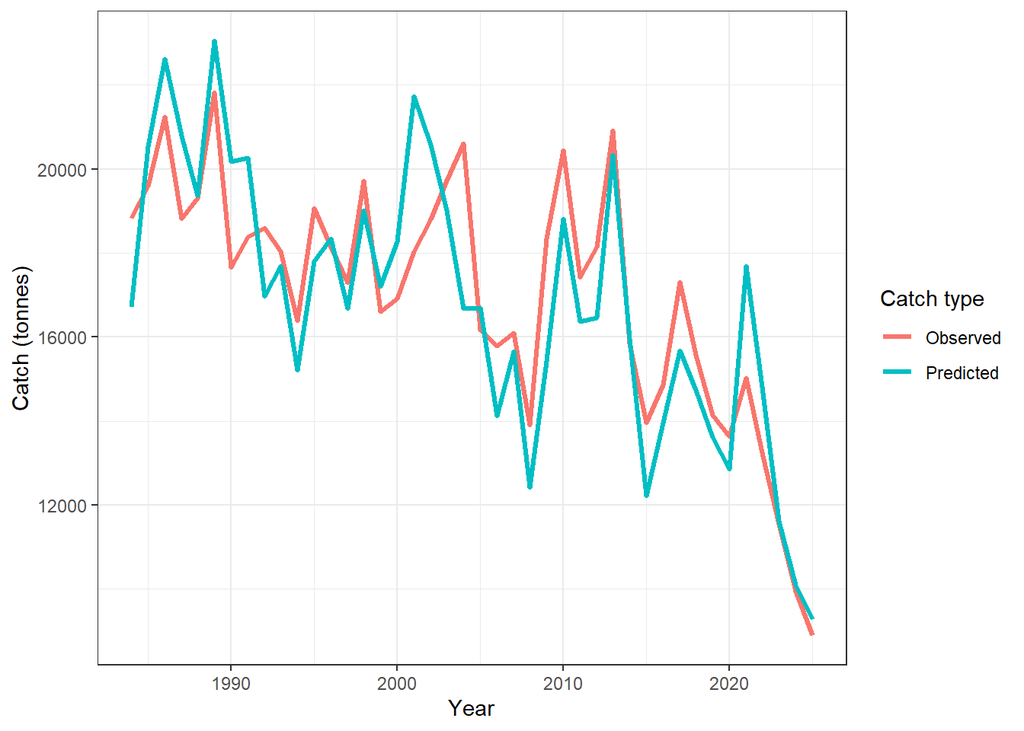

Figure 4: Comparison of observed and predicted catch in the 2026 assessment.

# Data corrections

## Historically, there was a strange outlier in IRLFR for recruitment (age-1) in 2011

For IRLFR index, the 2011 value was set to NA following the revisions adopted in the 2022 Megrim Benchmark (ICES 2023). However, due to the last update of the index in WGBIE2025, there is not a strange outlier in 2011, and the value of 2011 is similar to the one observed in 2009 and 2010 (Figure 5).

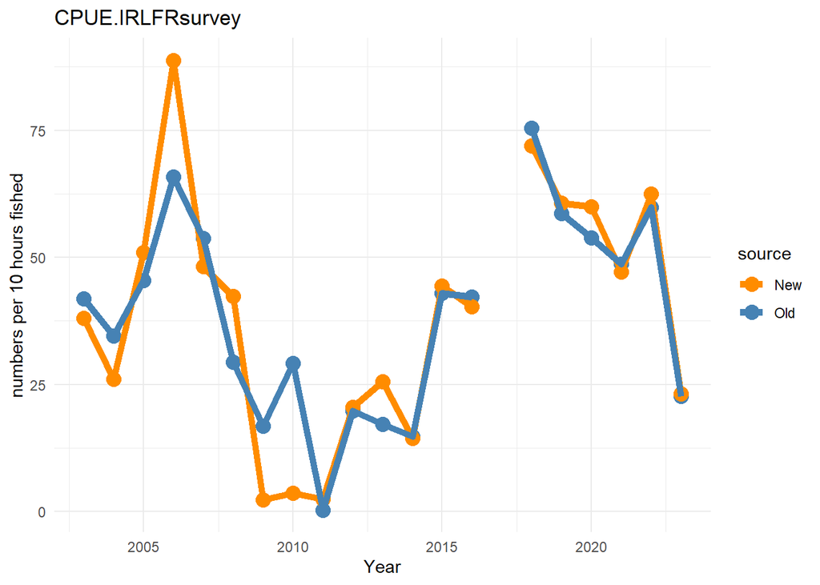

Figure 5: Age-1 IRLFR index.

I propose no removing 2011 values.

### Retrospective analysis plot

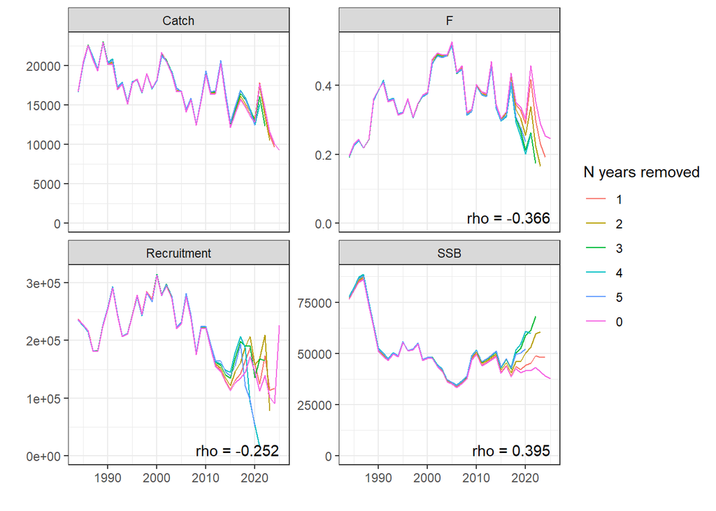

Figure 6: Retrospective analysis showing time series and Mohn’s rho values for median catch, fishing mortality (F, ages 3-6), recruitment (age 1), and spawning stock biomass (SSB), after correcting the no outliers in the IRLFR index data.

### Selectivity and catchability plot

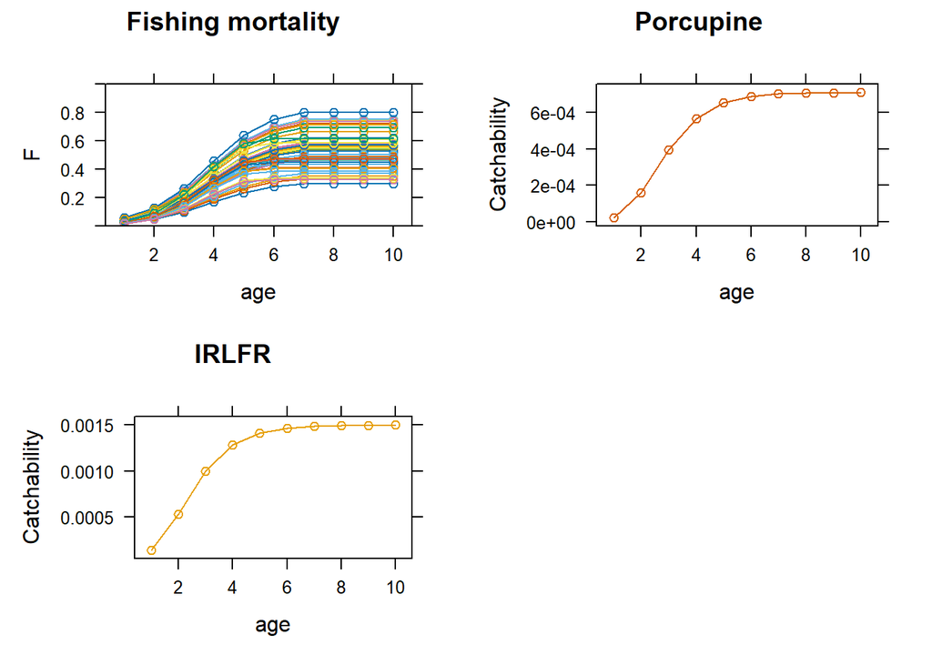

Figure 7: Fishery selectivity and indices catchabilities estimates from the assessment, after correcting the no outliers in the IRLFR index data.

### Residuals plot

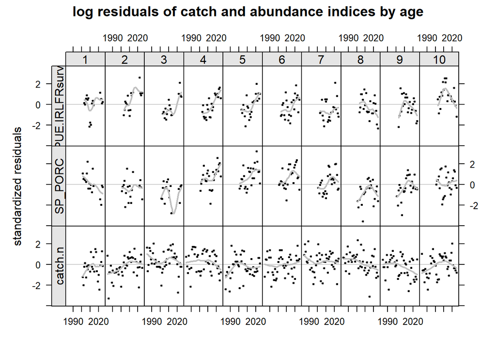

Figure 8: The catch-at-age and index-at-age (Porcupine and IRLFR) residuals in the assessment, after correcting the no outliers in the IRLFR index data.

### Observed and predicted catches plot

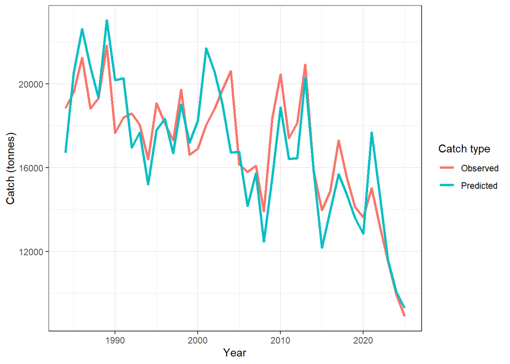

Figure 9: Comparison of observed and predicted catch in the assessment, after correcting the no outliers in the IRLFR index data.

## Error in Belgium 2022 Landings: Landings and Discards were summed

The number of individuals used in the assessment as landings for Belgium in 2022 was incorrect, as it actually corresponded to the sum of landings and discards (Figure 10).

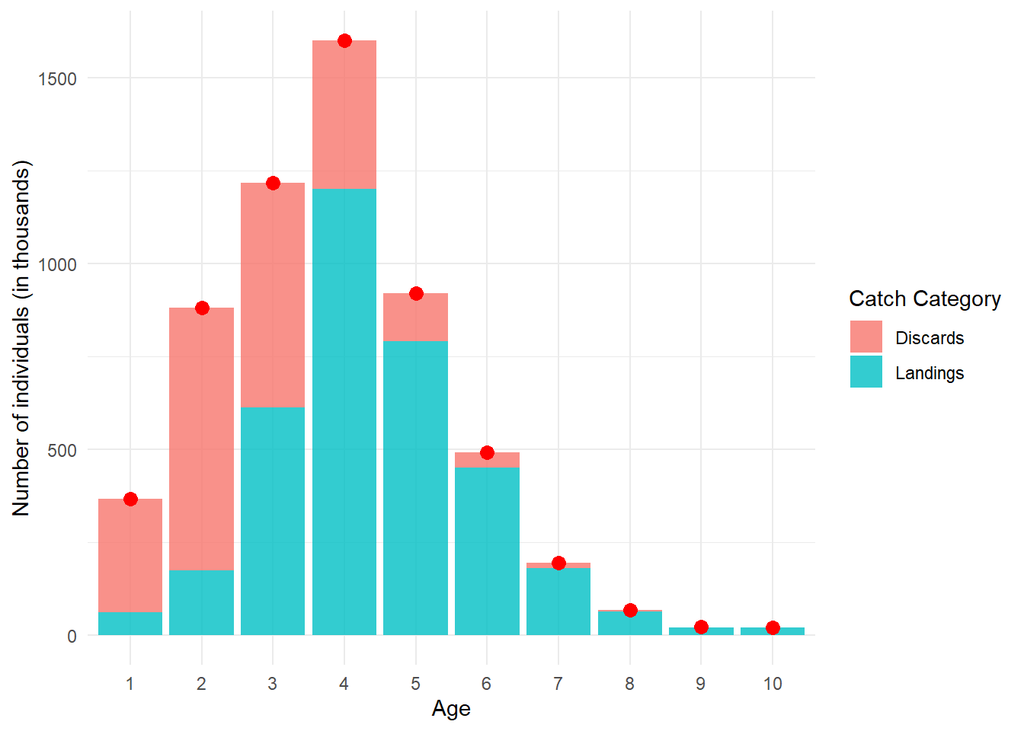

Figure 10: Comparison of Correct Catch Numbers vs. Erroneous Landings Values. Stacked bars represent the correct separation of Landings and Discards from intercatch for Belgium data in 2022. Red points indicate the erroneous Landings values used in the assessment dataset, where Landings mistakenly include both Landings and Discards.

### Changes in the model data

After correcting the Belgium number of individuals for 2022, the updated data show a differences in landings, and total catch compared with the pre-correction values but not in discards (Figure 11).

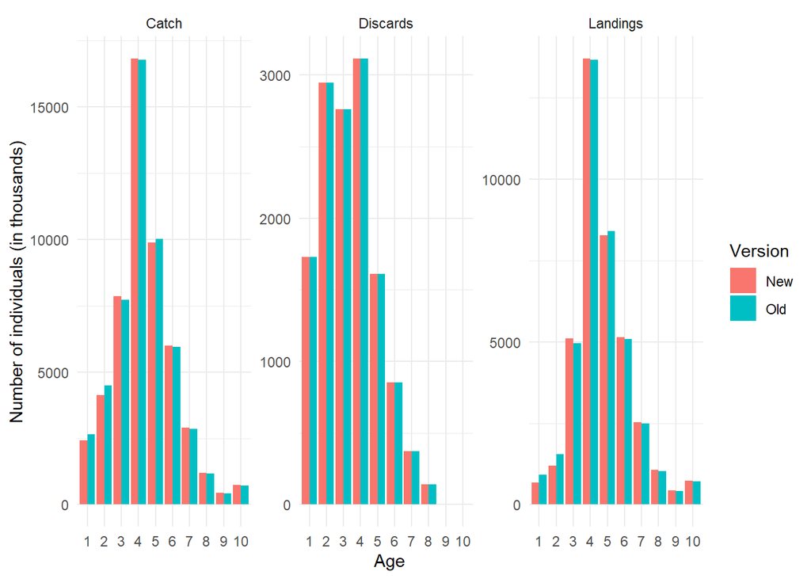

Figure 11: Comparison of Old vs New catch, landigns and discards number of individuals before and after the correction of the Belgium number of individuals in 2022.

### Retrospective analysis plot

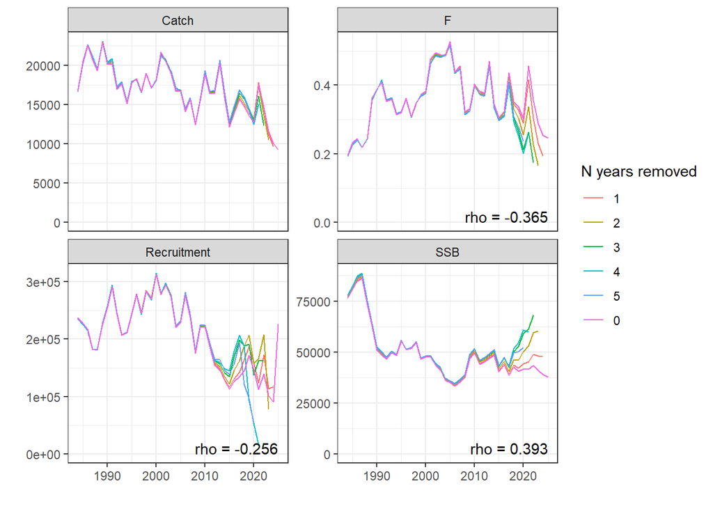

Figure 12: Retrospective analysis showing time series and Mohn’s rho values for median catch, fishing mortality (F, ages 3-6), recruitment (age 1), and spawning stock biomass (SSB), after the correction of the Belgium number of individuals in 2022.

### Selectivity and catchability plot

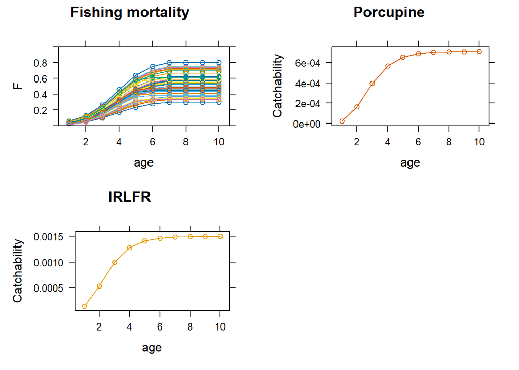

### Residuals plot

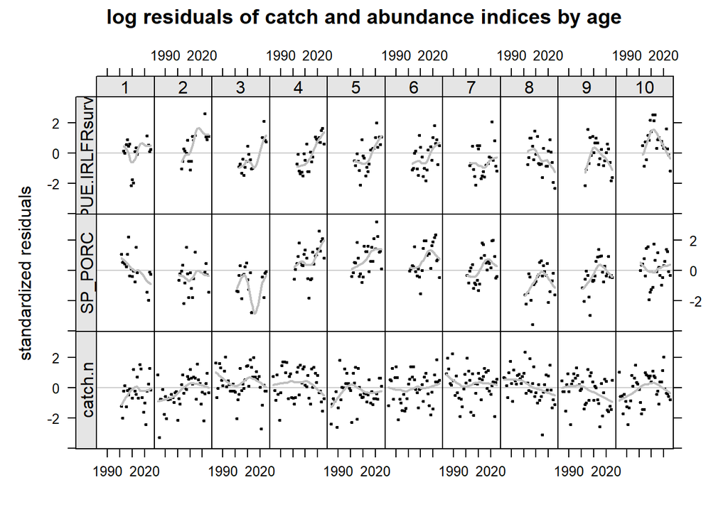

### Observed and predicted catches plot

The differences among observed and predicted catches are shown in (Figure 15).

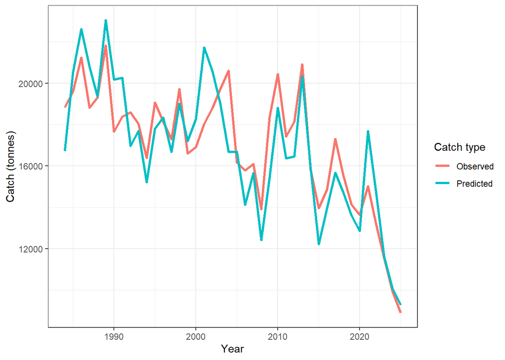

Figure 15: Comparison of observed and predicted catch in the assessment after the correction of the Belgium number of individuals in 2022.

# Model configuration

## Reduce the plus group to 7+

The plus group was reduced from 10+ to 7+ following the recommendation of the **external reviewer** in last year’s review-level benchmark, who advised lowering the plus group age to improve consistency and reliability in the assessment. This adjustment also aligns the model with the established plus group for **southern *Lepidorhombus whiffiagonis* stock**, which is 7+. In addition, notable differences in age‑reading criteria have been documented among participating countries, particularly for individuals aged 7 years and older, where **interpretation becomes less consistent** . A dedicated age‑reading workshop is scheduled for June 2026 to harmonize methodologies and reach a shared agreement on age determination across countries.

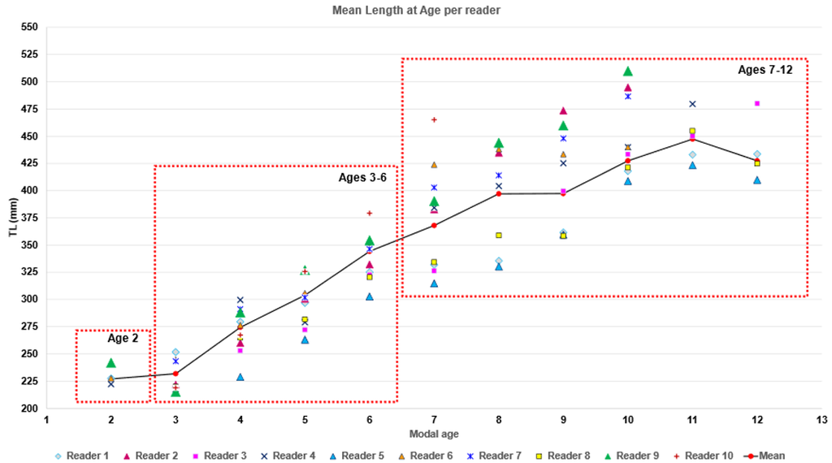

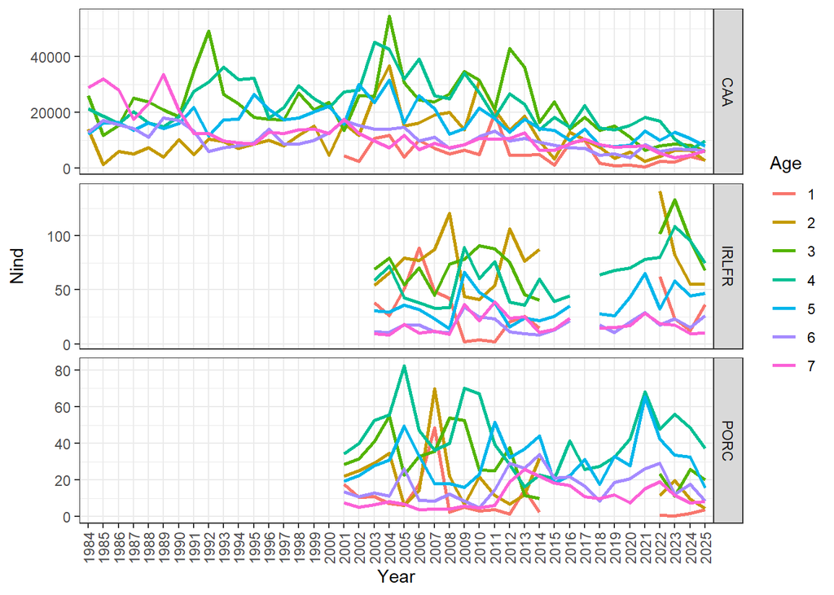

Figure 17: Time series of number of individuals-at-age in the catches, and in the both indices (IRLF and Porcupine). The unit of number of individuals is different; number of individuals in catch is in thousands, in Porcupine survey in mean catches per 30’ haul and in IRLFR survey in numbers per 10 hours fished.

### Retrospective analysis plot

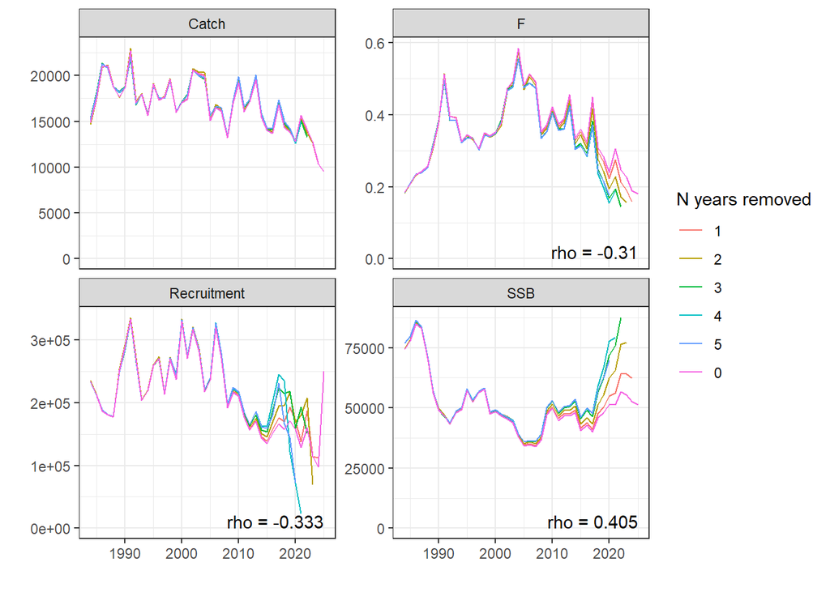

Figure 18: Retrospective analysis showing time series and Mohn’s rho values for median catch, fishing mortality (F, ages 3-6), recruitment (age 1), and spawning stock biomass (SSB), after reducing the plus group at 7.

### Selectivity and catchability plot

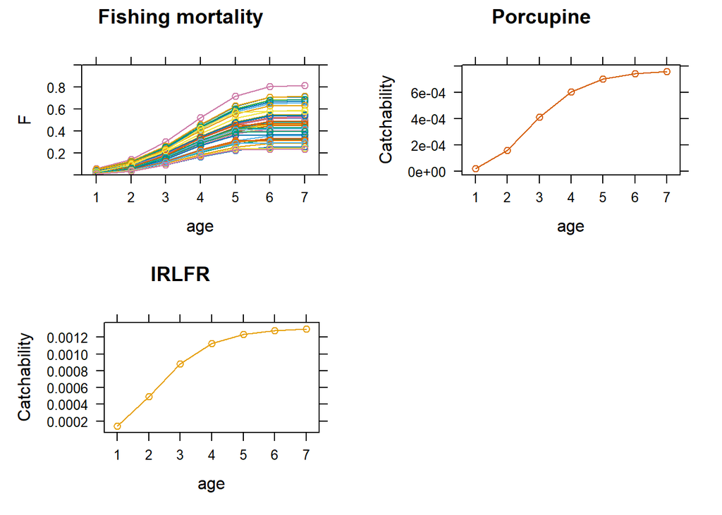

Figure 19: Fishery selectivity and indices catchabilities estimates from the assessment, after reducing the plus group at 7.

### Residuals plot

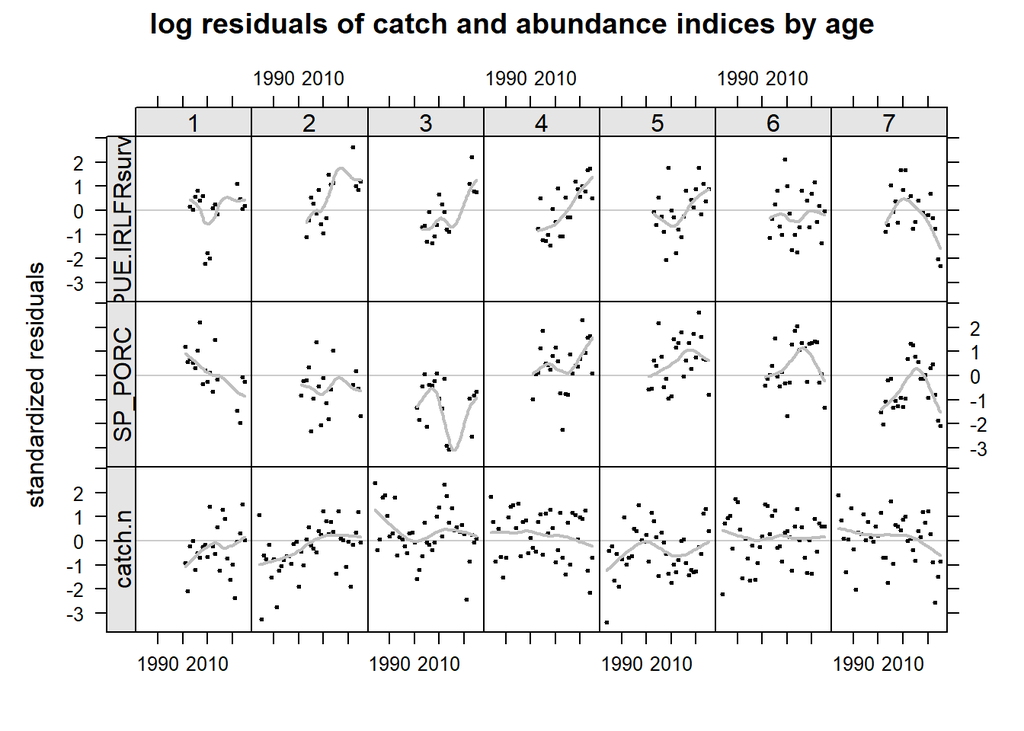

Figure 20: The catch-at-age and index-at-age (Porcupine and IRLFR) residuals in the assessment, after reducing the plus group at 7.

### Observed and predicted catches plot

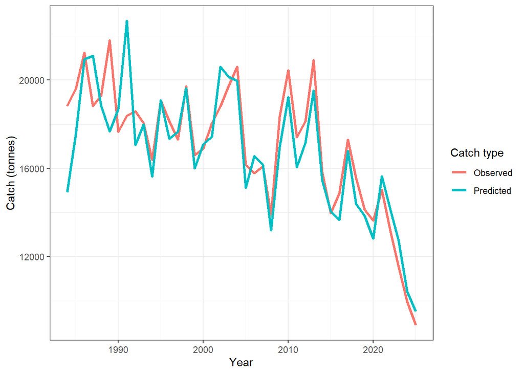

Figure 21: Comparison of observed and predicted catch in the assessment, after reducing the plus group at 7.

## Explore more flexible models for survey catchability, considering alternatives to flat-top assumptions.

Following the recommendation of the external reviewer in last year’s review‑level benchmark, which suggested exploring more flexible formulations for survey catchability rather than assuming a strictly logistic catchability function,

qmod <- list(~ I(1 / (1 + exp(-age))),~ I(1 / (1 + exp(-age))))

the logistic form was replaced with spline‑based catchability models for both survey indices:

qmod_alt <- list(~s(age, k = 4), ~s(age, k = 4))

This modification allows catchability to vary more flexibly with age, without imposing a predetermined logistic shape.

### Some plots

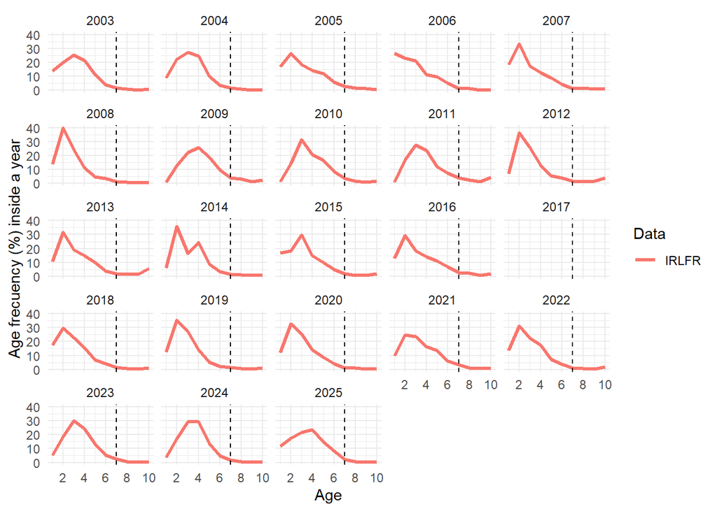

Figure 22: Time series of number of individuals-at-age frecuency distribution (in percentage) in the IRLF. Dashed line at age 7 (plus group age).

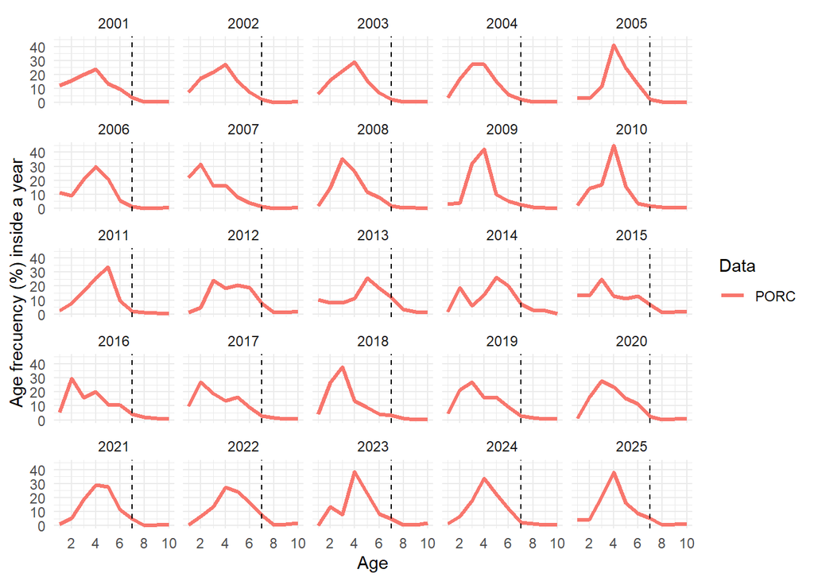

Figure 23: Time series of number of individuals-at-age frecuency distribution (in percentage) in the Porcupine. Dashed line at age 7 (plus group age).

### Retrospective analysis plot

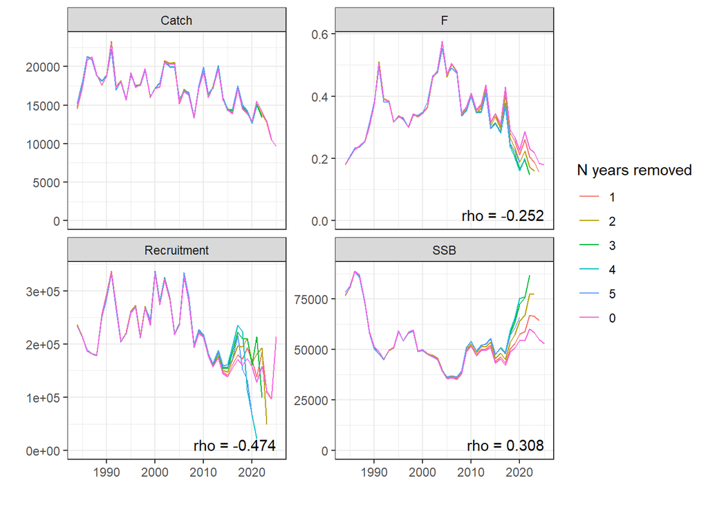

Figure 24: Retrospective analysis showing time series and Mohn’s rho values for median catch, fishing mortality (F, ages 3-6), recruitment (age 1), and spawning stock biomass (SSB), after changing the both index catchability models.

### Selectivity and catchability plot

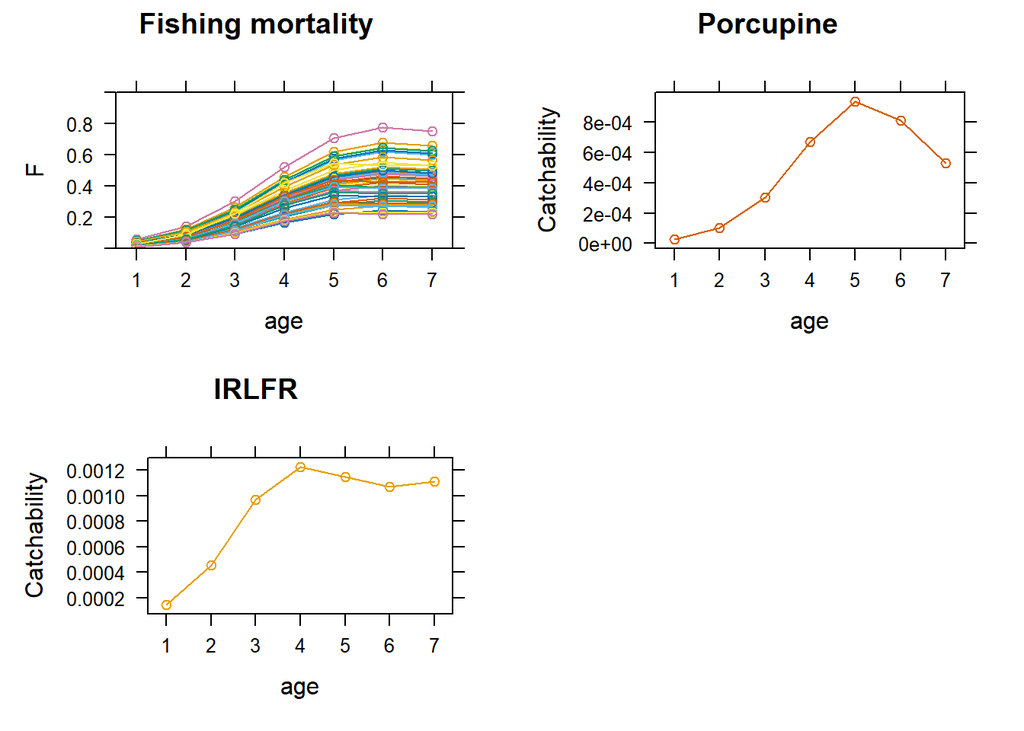

Figure 25: Fishery selectivity and indices catchabilities estimates from the assessment, after changing the both index catchability models.

### Residuals plot

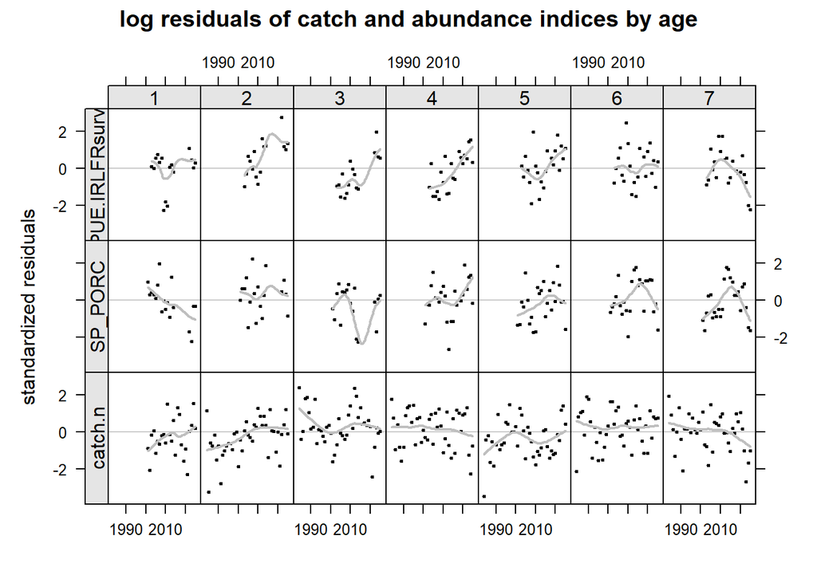

Figure 26: The catch-at-age and index-at-age (Porcupine and IRLFR) residuals in the assessment, after changing the both index catchability models.

### Observed and predicted catches plot

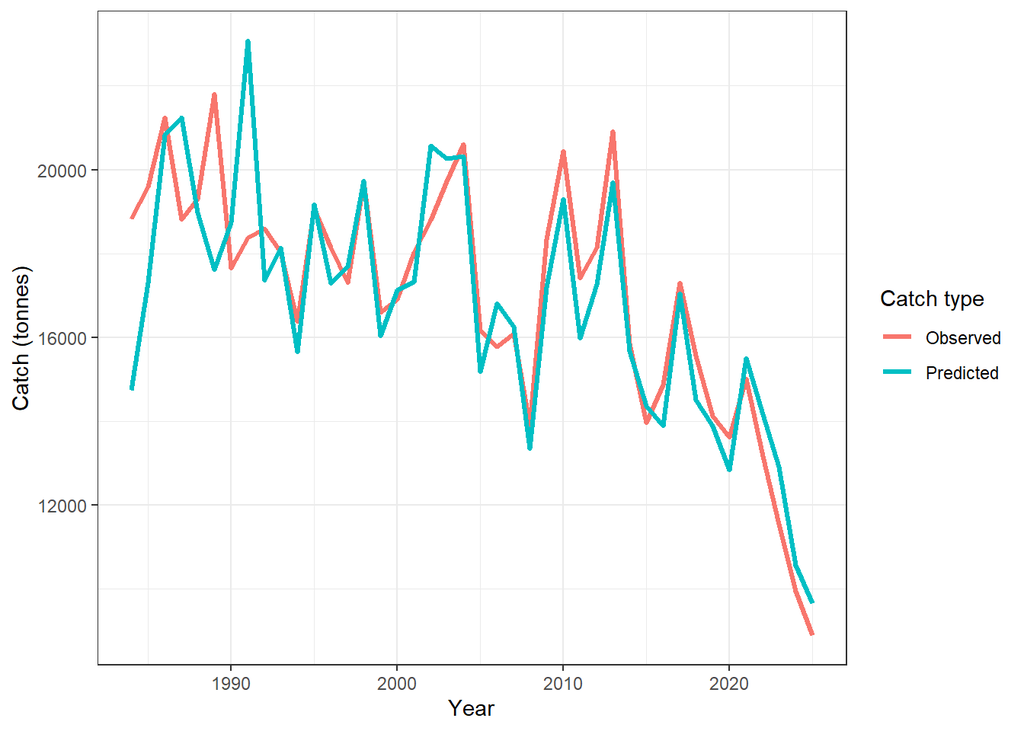

Figure 27: Comparison of observed and predicted catch in the assessment, after changing the both index catchability models.

## Explore more flexible models for fishing mortality, including time-varying selection patterns and alternatives to flat-top assumptions.

Following the external reviewer’s recommendation to “explore more flexible models for fishing mortality, including time‑varying selection patterns and alternatives to flat‑top assumptions”, the previous formulation based on a truncated logistic‑type structure

fmod <- ~s(ifelse(year <= 2013 & age > 7, 7, ifelse(year >= 2014 & age > 6, 6, age)), k = 3, by = breakpts(year, 2013)) + factor(year)

was replaced by spline‑based model:

fmod_alt <- ~s(age, k = 3, by = breakpts(year, c(2013))) + factor(year)

The spline‑based formulation allow fishing mortality to vary more flexibly across ages within each time block, avoiding the constraints imposed by a predetermined logistic or flat‑top shape.

### Some plots

Number of individuals-at-age frecuency distribution in the catches (Figure 28).

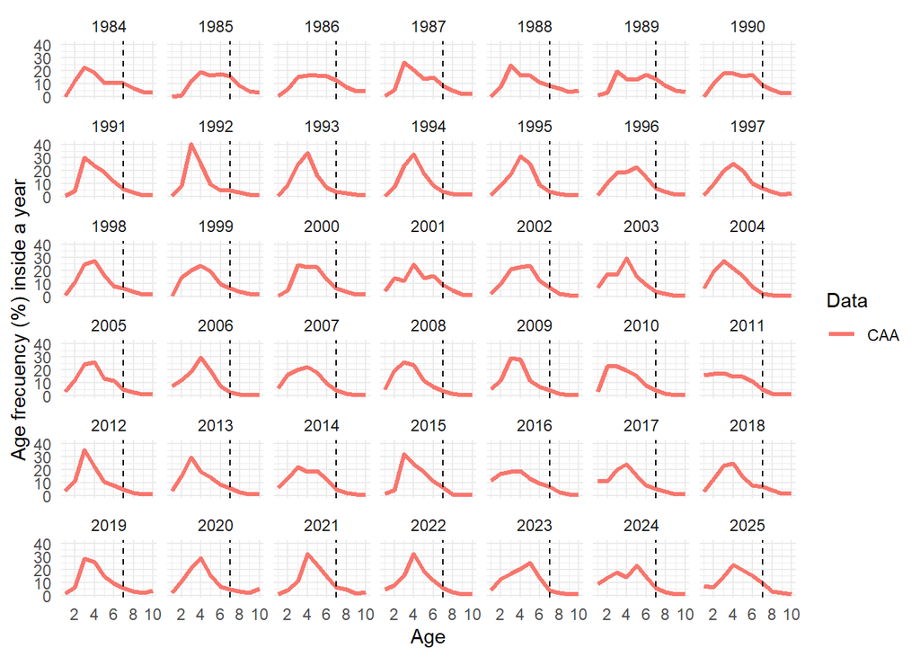

Figure 28: Time series of number of individuals-at-age frecuency distribution (in percentage) in the catches. Dashed line at age 7 (plus group age).

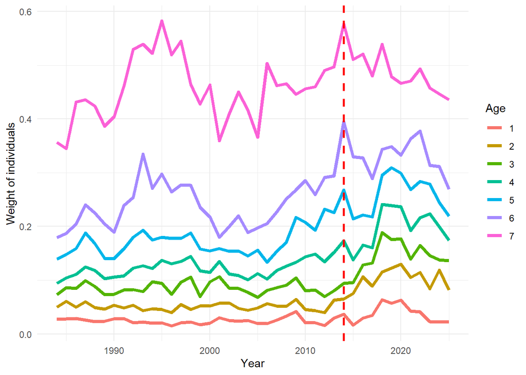

Figure 29: Time series of the weight-at-age of captured individuals, with the proposed 2014 breakpoint indicated by a dashed red line.

### Retrospective analysis plot

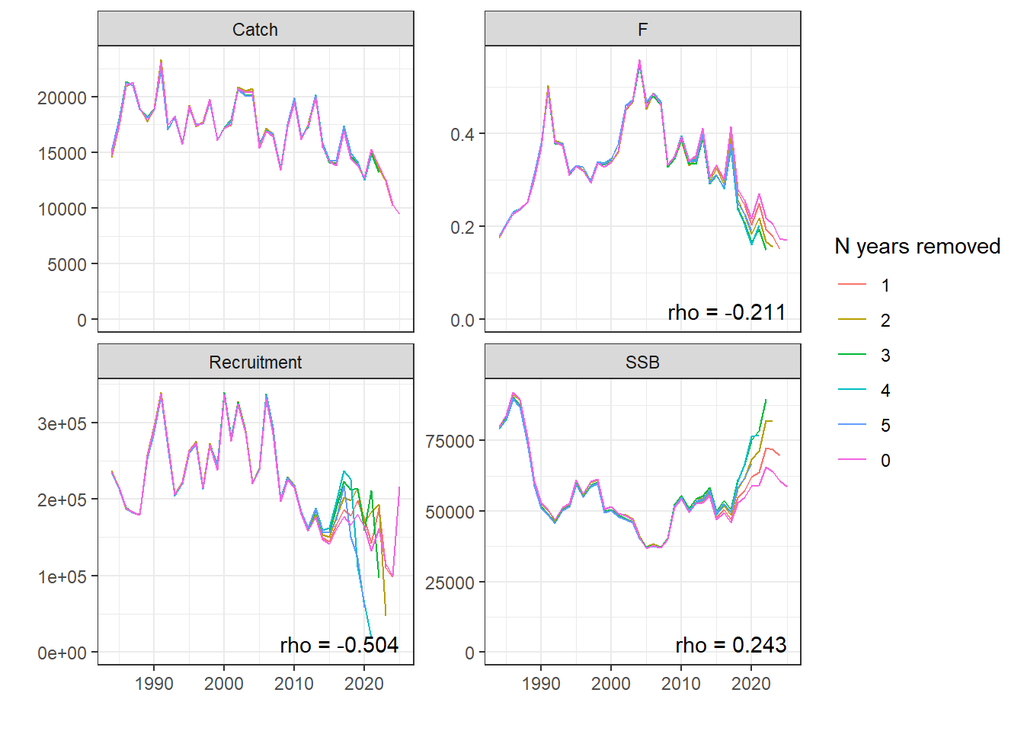

Figure 30: Retrospective analysis showing time series and Mohn’s rho values for median catch, fishing mortality (F, ages 3-6), recruitment (age 1), and spawning stock biomass (SSB), after changing the fishing mortality model.

### Selectivity and catchability plot

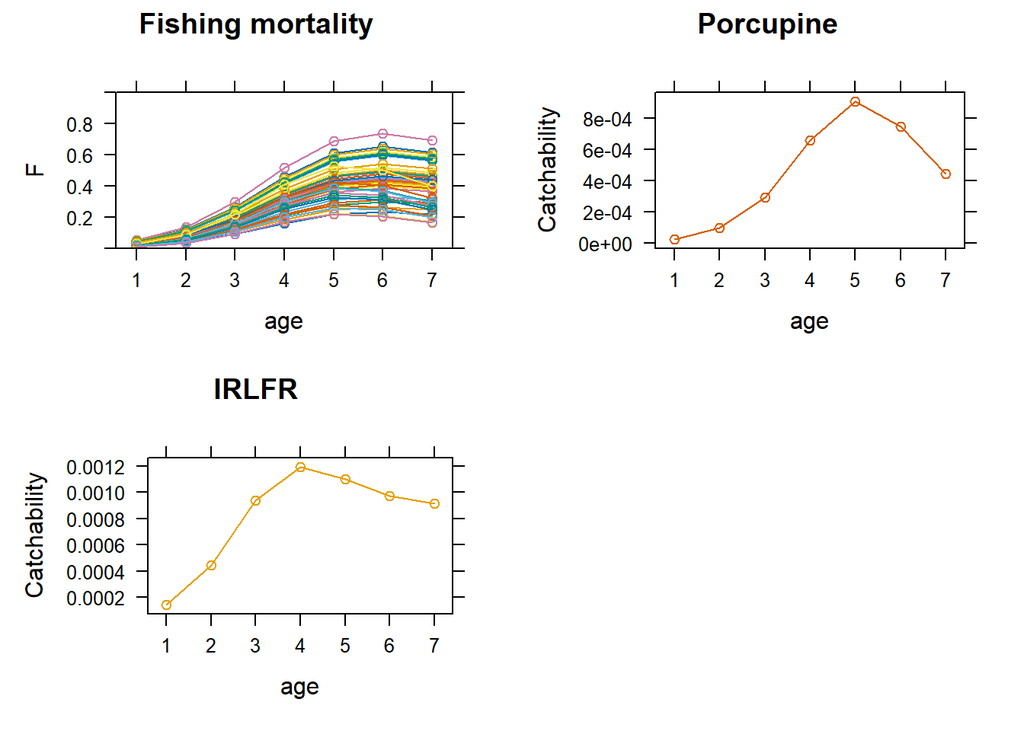

Figure 31: Fishery selectivity and indices catchabilities estimates from the assessment, after changing the fishing mortality model.